# Simulation Methods: Lab 1

Aleksi Patronen

2024-01-23

Could you please add in comments to your code alongwith a summary of your understading and resubmit?

a). Implement R-code of the Box-Müller algorithm for random generation of variable X from a normal distribution. Table 6.1 in Givens and Hoeting (2013) provides information on the algorithm. Compare the results with simulations from rnorm() in terms of summary statistics (mean and standard deviation) and a histogram based on n = 100 000 draws.

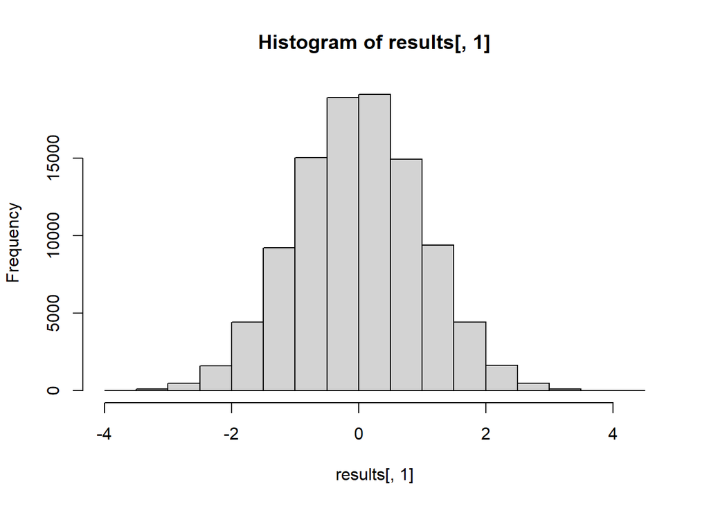

```r
library(ggplot2)
n <- 10^5 # number of observations simulated
seed <- 1234 # seed for reproducability
Box_muller <- function(n, mu, sigma, seed){
  set.seed(seed)
  samples <- matrix(ncol = 2, nrow = n) # create a matrix where samples will be stored
   for (i in c(1:n)){ # for loop 1 -> n
     u1 <- runif(1) # sample u1 from uniform
     u2 <- runif(1) # sample u2 from uniform
     R <- sqrt(-2*log(1 - u1)) # calculate the fist part of the norm equation
     theta <- 2*pi*u2 # the second part  as tabulated in table 6.1 in the book
     X <- R*cos(theta) # make two variables x and y
     Y <- R*sin(theta) # both of wich are normally distributed i.i.d
     samples[i,1] <- X # pack both of the variables into the matrix
     samples[i,2] <- Y # created earlier.
   }
  return(samples)  # return samples
}



results <- Box_muller(n, mu = 0, sigma = 1, seed) # call for the functions
hist(results[,1]) # lets hist's
```

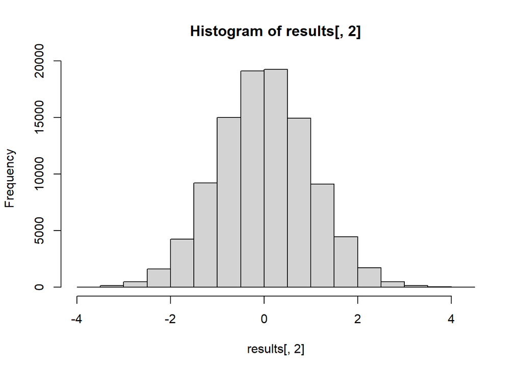

```r
hist(results[,2]) # lets hist's
```

```r
set.seed(seed) # lets see wheeather theres diffrerence to the standard rnorm function in R
results_standard <- rnorm(n)

summary(results[,1]) - summary(results_standard)
```

```
##       Min.    1st Qu.     Median       Mean    3rd Qu.       Max.
##  0.5259405 -0.0057226 -0.0011024 -0.0007772  0.0045539  0.3785699
```

```r
summary(results[,2]) - summary(results_standard)
```

```
##       Min.    1st Qu.     Median       Mean    3rd Qu.       Max.
##  0.5772140 -0.0007720 -0.0002304  0.0032985  0.0047722  0.2696428
```

Box-Müller and R standard rnorm() dont give exactly the same results. Slight deviation exist.

```r
summary(rowMeans(results)) - summary(results_standard) # lets see if averaging the two variabrles makes a difference
```

```
##      Min.   1st Qu.    Median      Mean   3rd Qu.      Max.
##  1.568507  0.192989 -0.001510  0.001261 -0.189716 -0.986370
```

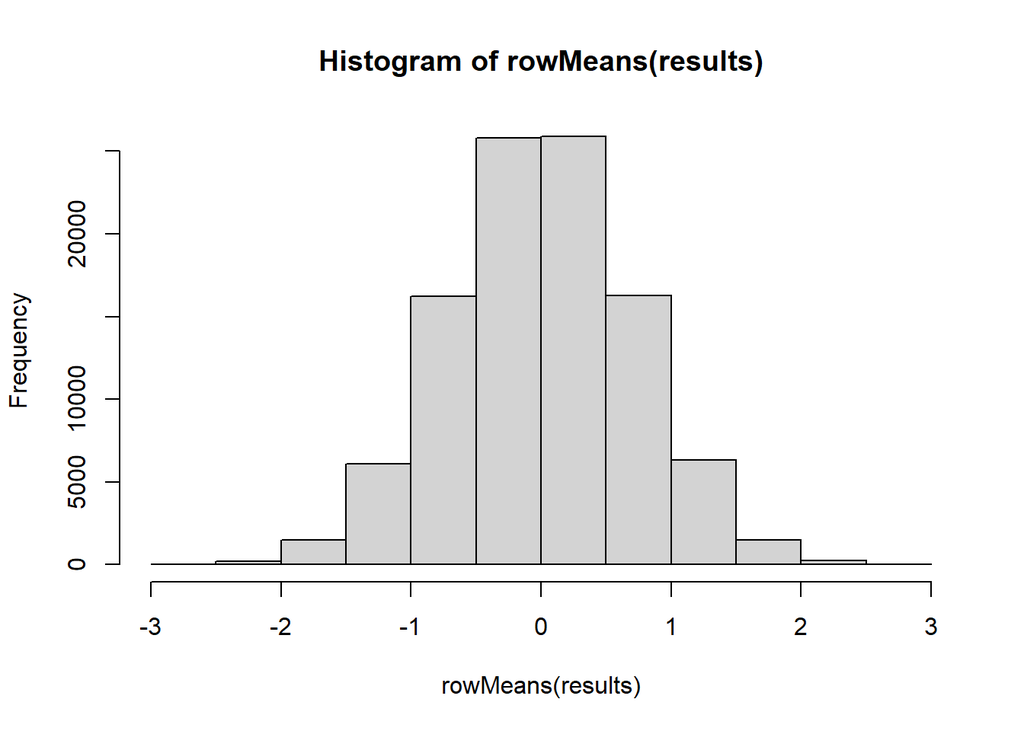

```r
hist(rowMeans(results))
```

averaging the two different variables doesn’t help.

b). Make a for loop (or something equivalent) and produce 100 replicate data sets of the set-up in the earlier part of the exercise. Use the mean to calculate expectations for each of these, and finally calculate the standard deviation of the means. Repeat this procedure with n = 100, 1 000 and 10 000. Present a table with n and the standard deviation of the means. Discuss your result and present the R-code you together with explaination # comments.

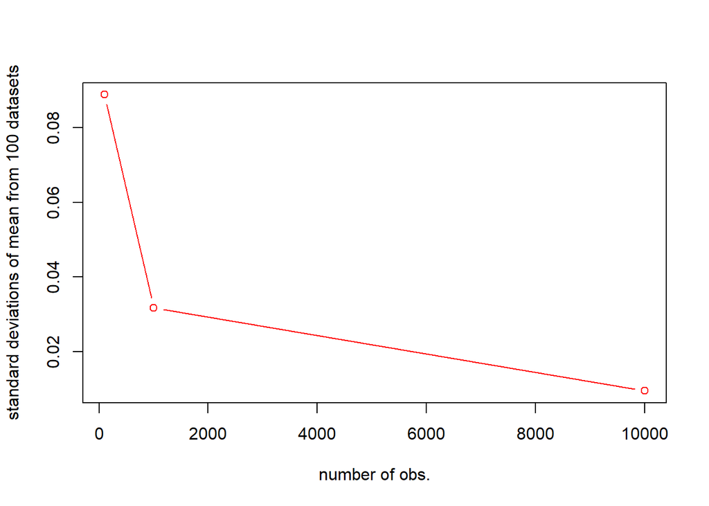

```r
plot(ns,deviations, type = "b", xlab = "number of obs.", ylab = "standard deviations of mean from 100 datasets", col = "red")
```

```r
matrix(c(ns, deviations), nrow = 3, ncol = 2)
```

```
##       [,1]        [,2]
## [1,]   100 0.088828676
## [2,]  1000 0.031657276
## [3,] 10000 0.009486112
```

This is matrix (numeric) representation of the previous graph